# The most severe weather events in the United States in terms of the population health and the economic consequences

Marcin Zakidalski

23 05 2021

## The synopsis

This analysis is going to answer the following two questions:

1. Across the United States, which types of events (as indicated in the EVTYPE variable) are most harmful with respect to population health?
2. Across the United States, which types of events have the greatest economic consequences?

The data used in this analysis comes from the following source: https://d396qusza40orc.cloudfront.net/repdata%2Fdata%2FStormData.csv.bz2.

## Data Processing

R packages used in the analysis:

```r
library(readr)
library(ggplot2)
library(dplyr)
library(stringr)
```

From the data set we are interested only in the following columns:

- STATE - code abbreviating the state
- BGN_DATE, END_DATE - event start/end dates
- PROPDMG / CROPDMG - describes the damage to the property/crop
- PROPDMGEXP / CROPDMGEXP - multipliers to the previous values (k/K for 1000, m/M for 1 000 000, b/B for 1 000 000 000).

Data loading & column selection (we assume that the download dataset is present in the working folder):

```r
all_weather_data <- read_csv("repdata_data_StormData.csv.bz2")
filtered_cols_data <- all_weather_data %>% select(STATE, BGN_DATE, END_DATE,
                                                  EVTYPE,
                                                  PROPDMG, PROPDMGEXP, CROPDMG,
                                                  CROPDMGEXP, INJURIES, FATALITIES)
```

The filtered_cols_data dataframe contains the rows “Summary…” and “?” ENVTYPEs which should be deleted. Additionally event names are transformed to the uppercase:

```r
head(filtered_cols_data %>% filter (str_detect(EVTYPE, "[Ss][Uu][Mm][Mm][Aa][Rr][Yy]")) %>% select(EVTYPE))
```

```
## # A tibble: 6 x 1
##   EVTYPE
##   <chr>
## 1 Summary Jan 17
## 2 Summary of March 14
## 3 Summary of March 23
## 4 Summary of March 24
## 5 Summary of April 3rd
## 6 Summary of April 12
```

```r
filtered_cols_data <- filtered_cols_data %>% filter (!str_detect(EVTYPE, "[Ss][Uu][Mm][Mm][Aa][Rr][Yy]")) %>%
                      filter (!str_detect(EVTYPE, "\\?")) %>%
                      mutate(EVTYPE = toupper(EVTYPE))
```

According to the documentation of the dataset the COLNAME*EXP columns contain the multiplier for the COLNAME values. This data contains not only tidy values:

```r
print( unique(filtered_cols_data$PROPDMGEXP))
```

```
##  [1] "K" "M" NA  "B" "m" "+" "0" "5" "6" "?" "4" "2" "3" "h" "7" "H" "-" "1" "8"
```

```r
print( unique(filtered_cols_data$CROPDMGEXP))
```

```
## [1]    NA FALSE
```

The analysis assumption is that:

- allowed multipliers are B, M (which is equivalent to m), K
- all other values (including NAs) are equivalent to 1.0 multiplier

The ALL_* columns will contain the real value (in $) of damages:

```r
filtered_cols_data <- filtered_cols_data %>%
                          mutate(ALL_PROPDMG = case_when( endsWith(PROPDMGEXP,"B")  ~ 1000000000.0*PROPDMG,
                                                          endsWith(PROPDMGEXP, "M") ~ 1000000.0*PROPDMG,
                                                          endsWith(PROPDMGEXP, "m") ~ 1000000.0*PROPDMG,
                                                          endsWith(PROPDMGEXP, "K") ~ 1000.0*PROPDMG,
                                                          TRUE ~ 1.0*PROPDMG))

# there are no multipliers for the crop-related damage
filtered_cols_data <- filtered_cols_data %>% mutate(ALL_CROPDMG = CROPDMG)
```

We can briefly verify our transformations are correct:

```r
head(filtered_cols_data %>% filter(PROPDMG > 0) %>% select(-STATE, -BGN_DATE, -END_DATE))
```

```
## # A tibble: 6 x 9
##   EVTYPE PROPDMG PROPDMGEXP CROPDMG CROPDMGEXP INJURIES FATALITIES ALL_PROPDMG
##   <chr>    <dbl> <chr>        <dbl> <lgl>         <dbl>      <dbl>       <dbl>
## 1 TORNA~    25   K                0 NA               15          0       25000
## 2 TORNA~     2.5 K                0 NA                0          0        2500
## 3 TORNA~    25   K                0 NA                2          0       25000
## 4 TORNA~     2.5 K                0 NA                2          0        2500
## 5 TORNA~     2.5 K                0 NA                2          0        2500
## 6 TORNA~     2.5 K                0 NA                6          0        2500
## # ... with 1 more variable: ALL_CROPDMG <dbl>
```

```r
head(filtered_cols_data %>% filter(CROPDMG > 0) %>% select(-STATE, -BGN_DATE, -END_DATE))
```

```
## # A tibble: 6 x 9
##   EVTYPE PROPDMG PROPDMGEXP CROPDMG CROPDMGEXP INJURIES FATALITIES ALL_PROPDMG
##   <chr>    <dbl> <chr>        <dbl> <lgl>         <dbl>      <dbl>       <dbl>
## 1 HURRI~     0.1 B               10 NA                0          2   100000000
## 2 THUND~     5   M              500 NA                0          0     5000000
## 3 HURRI~    25   M                1 NA                0          0    25000000
## 4 HURRI~    48   M                4 NA                0          0    48000000
## 5 HURRI~    20   m               10 NA                0          0    20000000
## 6 THUND~    50   K               50 NA                0          0       50000
## # ... with 1 more variable: ALL_CROPDMG <dbl>
```

Finally, we prepare the summary dataframe to work further on:

```r
events_summary <- filtered_cols_data %>% select(EVTYPE, INJURIES, FATALITIES, ALL_PROPDMG, ALL_CROPDMG) %>%
                                         mutate(ALL_DMG = ALL_PROPDMG + ALL_CROPDMG) %>%
                                         select(-ALL_PROPDMG, -ALL_CROPDMG) %>%
                                         group_by(EVTYPE) %>%
                                         summarise(across(where(is.numeric), sum))
events_summary$EVTYPE <- as.factor(events_summary$EVTYPE)
head(events_summary)
```

```
## # A tibble: 6 x 4
##   EVTYPE               INJURIES FATALITIES ALL_DMG
##   <fct>                   <dbl>      <dbl>   <dbl>
## 1 ABNORMAL WARMTH             0          0     0
## 2 ABNORMALLY DRY              0          0     0
## 3 ABNORMALLY WET              0          0     0
## 4 ACCUMULATED SNOWFALL        0          0     0
## 5 AGRICULTURAL FREEZE         0          0    28.8
## 6 APACHE COUNTY               0          0  5000
```

## Results

Here are the answers to the questions stated in the synopsis: 1. We define the events which are most harmful with respect to population health as fulfilling any of the following conditions:

- top five events according to the cumulative fatalities across all data from the dataset

```r
answer_1a <- events_summary %>% arrange(desc(FATALITIES)) %>% select (EVTYPE, FATALITIES)
head(answer_1a, n=5)
```

```
## # A tibble: 5 x 2
##   EVTYPE         FATALITIES
##   <fct>               <dbl>
## 1 TORNADO              5633
## 2 EXCESSIVE HEAT       1903
## 3 FLASH FLOOD           978
## 4 HEAT                  937
## 5 LIGHTNING             816
```

- top five events according to the cumulative injuries across all data from the dataset

```r
answer_1b <- events_summary %>% arrange(desc(INJURIES)) %>% select (EVTYPE, INJURIES)
head(answer_1b, n=5)
```

```
## # A tibble: 5 x 2
##   EVTYPE         INJURIES
##   <fct>             <dbl>
## 1 TORNADO           91346
## 2 TSTM WIND          6957
## 3 FLOOD              6789
## 4 EXCESSIVE HEAT     6525
## 5 LIGHTNING          5230
```

2. We define the events with the top economic influence as those causing top 5 cumulative damage costs across all the dataset

```r
answer_2 <- events_summary %>% arrange(desc(ALL_DMG)) %>% select (EVTYPE, ALL_DMG)
head(answer_2, n=5)
```

```
## # A tibble: 5 x 2
##   EVTYPE                  ALL_DMG
##   <fct>                     <dbl>
## 1 FLOOD             144657877845.
## 2 HURRICANE/TYPHOON  69305844798.
## 3 TORNADO            56937260797.
## 4 STORM SURGE        43323536005
## 5 FLASH FLOOD        16141041268.
```

We can also see a histogram of those costs:

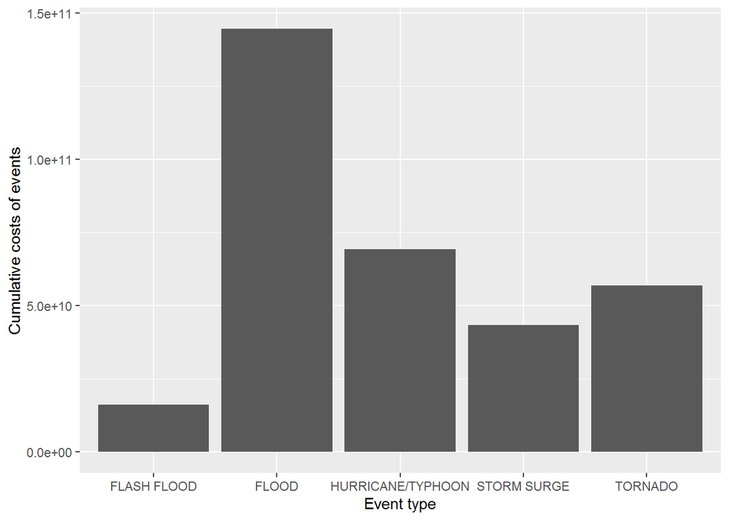

```r
answer_2 <- answer_2 %>% top_n(ALL_DMG, n=5)
ggplot(answer_2, aes(x=EVTYPE, y=ALL_DMG)) +geom_bar(stat="identity")+
      xlab("Event type") + ylab("Cumulative costs of events")
```